# Case Study – The Lending Club

2020-10-08

This workshop partially replicates the analysis presented in class (lectures 1 and 2) and builds on it. You are to work in your study group. Feel free to refer to the “Lending_Club_Session1_and_2.html” if you get stuck.

The workshop consists of 10 questions plus an optional question. Submit one report per group. *Please write your answers after each question and submit a knitted RMD markup file via canvas within 6 days after the end of this workshop.* Please keep your answers concise – focus on answering what you are asked and use your data science work to justify your answers. Do not focus on the process you have followed to reach the answer.

# Load and prepare the data

We start by loading the data to R in a dataframe.

```r
lc_raw <- read_csv("/Users/dl/Documents/MAM/individual_portfolio/data/LendingClub Data.csv",  skip=1) %>%  clean_names() # use janitor::clean_names()
```

# ICE the data: Inspect, Clean, Explore

Any data science engagement starts with ICE. Inspect, Clean and Explore the data. For this workshop I have cleaned the data for you.

```r
glimpse(lc_raw)
```

```
## Rows: 42,538
## Columns: 80
## $ int_rate            <dbl> 0.05, 0.05, 0.05, 0.05, 0.05, 0.05, 0.05, 0.05, 0…
## $ loan_amnt           <dbl> 8000, 6000, 6500, 8000, 5500, 6000, 10200, 15000,…
## $ term_months         <dbl> 36, 36, 36, 36, 36, 36, 36, 36, 36, 36, 36, 36, 3…
## $ installment         <dbl> 241.28, 180.96, 196.04, 241.28, 165.88, 180.96, 3…
## $ dti                 <dbl> 2.11, 5.73, 17.68, 22.71, 5.75, 21.92, 18.62, 9.7…
## $ delinq_2yrs         <dbl> 0, 0, 0, 0, 0, 0, 0, 0, 0, 0, 0, 0, 0, 0, 0, 0, 0…
## $ annual_inc          <dbl> 50000, 52800, 35352, 79200, 240000, 89000, 110000…
## $ grade               <chr> "A", "A", "A", "A", "A", "A", "A", "A", "A", "A",…
## $ emp_title           <chr> NA, "coral graphics", NA, "Honeywell", "O T Plus,…
## $ emp_length          <chr> "5 years", "< 1 year", "n/a", "n/a", "10+ years",…
## $ home_ownership      <chr> "MORTGAGE", "MORTGAGE", "MORTGAGE", "MORTGAGE", "…
## $ verification_status <chr> "Verified", "Source Verified", "Not Verified", "V…
## $ issue_d             <chr> "9/1/2011", "9/1/2011", "9/1/2011", "9/1/2011", "…
```

[output cut: 67 more lines]

```r
lc_clean<- lc_raw %>%
  dplyr::select(-x20:-x80) %>% #delete empty columns
  filter(!is.na(int_rate)) %>%   #delete empty rows
  mutate(
    issue_d = mdy(issue_d),  # lubridate::mdy() to fix date format
    term = factor(term_months),     # turn 'term' into a categorical variable
    delinq_2yrs = factor(delinq_2yrs) # turn 'delinq_2yrs' into a categorical variable
  ) %>%
  dplyr::select(-emp_title,-installment, -term_months, everything()) %>% mutate(emp_length=as.factor(emp_length)) #move some not-so-important variables to the end.


glimpse(lc_clean)
```

```
## Rows: 37,869
## Columns: 20
## $ int_rate            <dbl> 0.05, 0.05, 0.05, 0.05, 0.05, 0.05, 0.05, 0.05, 0…
## $ loan_amnt           <dbl> 8000, 6000, 6500, 8000, 5500, 6000, 10200, 15000,…
## $ dti                 <dbl> 2.11, 5.73, 17.68, 22.71, 5.75, 21.92, 18.62, 9.7…
## $ delinq_2yrs         <fct> 0, 0, 0, 0, 0, 0, 0, 0, 0, 0, 0, 0, 0, 0, 0, 0, 0…
## $ annual_inc          <dbl> 50000, 52800, 35352, 79200, 240000, 89000, 110000…
## $ grade               <chr> "A", "A", "A", "A", "A", "A", "A", "A", "A", "A",…
## $ emp_length          <fct> 5 years, < 1 year, n/a, n/a, 10+ years, 2 years, …
## $ home_ownership      <chr> "MORTGAGE", "MORTGAGE", "MORTGAGE", "MORTGAGE", "…
## $ verification_status <chr> "Verified", "Source Verified", "Not Verified", "V…
## $ issue_d             <date> 2011-09-01, 2011-09-01, 2011-09-01, 2011-09-01, …
## $ zip_code            <chr> "977xx", "228xx", "864xx", "322xx", "278xx", "760…
## $ addr_state          <chr> "OR", "VA", "AZ", "FL", "NC", "TX", "CT", "WA", "…
## $ loan_status         <chr> "Fully Paid", "Charged Off", "Fully Paid", "Fully…
## $ desc                <chr> "Borrower added on 09/08/11 > Consolidating debt …
## $ purpose             <chr> "debt_consolidation", "vacation", "credit_card", …
## $ title               <chr> "Credit Card Payoff $8K", "bad choice", "Credit C…
## $ term                <fct> 36, 36, 36, 36, 36, 36, 36, 36, 36, 36, 36, 36, 3…
## $ term_months         <dbl> 36, 36, 36, 36, 36, 36, 36, 36, 36, 36, 36, 36, 3…
## $ installment         <dbl> 241.28, 180.96, 196.04, 241.28, 165.88, 180.96, 3…
## $ emp_title           <chr> NA, "coral graphics", NA, "Honeywell", "O T Plus,…
```

```r
summary(lc_clean)
```

```
##     int_rate        loan_amnt          dti         delinq_2yrs
##  Min.   :0.0500   Min.   :  500   Min.   : 0.00   0      :33782
##  1st Qu.:0.0900   1st Qu.: 5500   1st Qu.: 8.14   1      : 3141
##  Median :0.1200   Median :10000   Median :13.36   2      :  637
##  Mean   :0.1203   Mean   :11253   Mean   :13.28   3      :  213
##  3rd Qu.:0.1500   3rd Qu.:15000   3rd Qu.:18.58   4      :   56
##  Max.   :0.2500   Max.   :35000   Max.   :29.99   5      :   22
##                                                   (Other):   18
##    annual_inc         grade               emp_length    home_ownership
##  Min.   :   4000   Length:37869       10+ years: 8405   Length:37869
##  1st Qu.:  40800   Class :character   < 1 year : 4384   Class :character
##  Median :  59534   Mode  :character   2 years  : 4168   Mode  :character
##  Mean   :  69148                      3 years  : 3910
##  3rd Qu.:  82800                      4 years  : 3305
##  Max.   :6000000                      5 years  : 3146
##                                       (Other)  :10551
##  verification_status    issue_d             zip_code          addr_state
##  Length:37869        Min.   :2007-06-01   Length:37869       Length:37869
##  Class :character    1st Qu.:2010-05-01   Class :character   Class :character
##  Mode  :character    Median :2011-02-01   Mode  :character   Mode  :character
##                      Mean   :2010-11-05
##                      3rd Qu.:2011-08-01
##                      Max.   :2011-12-01
##
##  loan_status            desc             purpose             title
##  Length:37869       Length:37869       Length:37869       Length:37869
##  Class :character   Class :character   Class :character   Class :character
##  Mode  :character   Mode  :character   Mode  :character   Mode  :character
##
##
##
##
##  term        term_months     installment       emp_title
##  36:27674   Min.   :36.00   Min.   :  15.68   Length:37869
##  60:10195   1st Qu.:36.00   1st Qu.: 168.59   Class :character
##             Median :36.00   Median : 288.33   Mode  :character
##             Mean   :42.46   Mean   : 332.58
##             3rd Qu.:60.00   3rd Qu.: 449.05
##             Max.   :60.00   Max.   :1305.19
##
```

The data is now in a clean format stored in the dataframe “lc_clean.”

# Q1. Explore the data by building some visualizations as suggested below. Fill free to add your own.

Provide your answers in the code block below. (Look at the “Lending_Club_Session1_and_2.html” for some hints on how to do this using ggplot.)

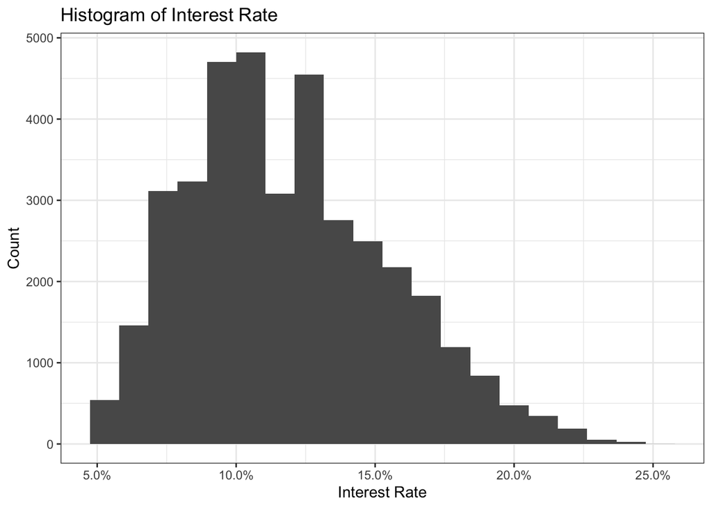

```r
# Build a histogram of interest rates. Make sure it looks nice!
ggplot(lc_clean, aes(x=int_rate))+
  geom_histogram(bins=20) +
  labs(title="Histogram of Interest Rate",
       x="Interest Rate",
       y="Count")+
  scale_x_continuous(labels = scales::percent)+
  theme_bw()
```

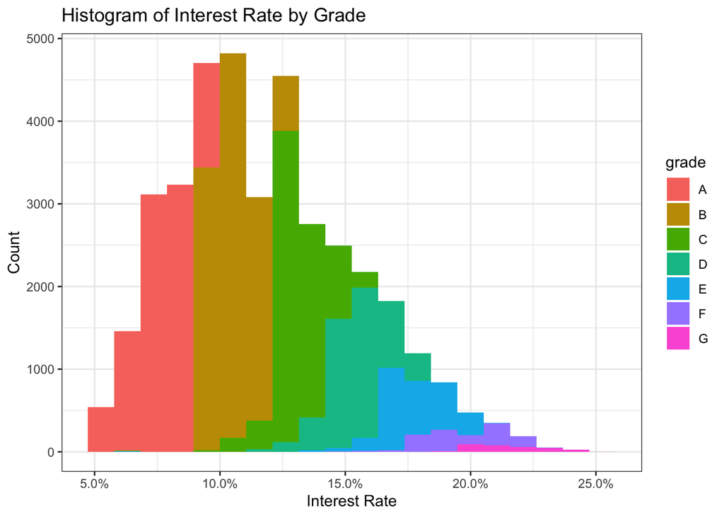

```r
# Build a histogram of interest rates but use different color for loans of different grades
ggplot(lc_clean, aes(x=int_rate, fill=grade))+
  geom_histogram(bins=20)+
  labs(title="Histogram of Interest Rate by Grade",
       x="Interest Rate",
       y="Count")+
  scale_x_continuous(labels = scales::percent)+
  theme_bw()
```

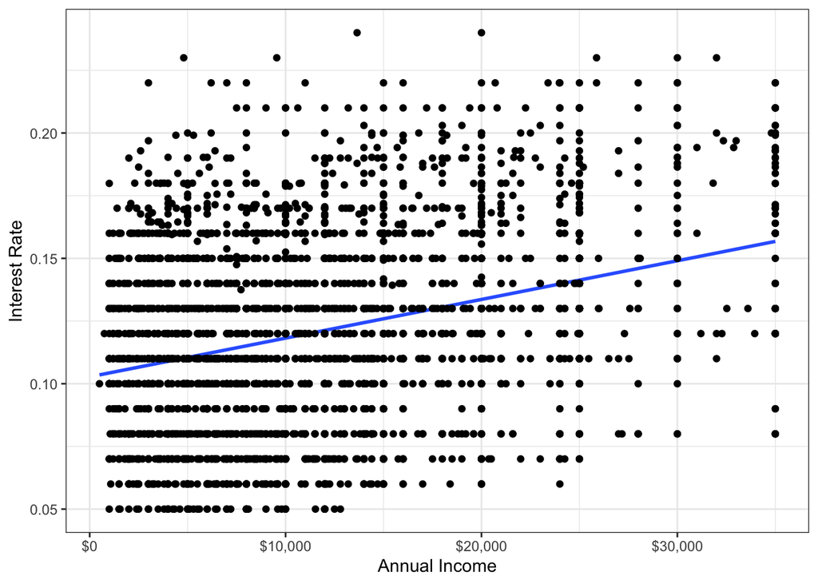

```r
# Produce a scatter plot of loan amount against interest rate and add visually the line of best fit
ggplot(lc_clean[seq(1, nrow(lc_clean), 10), ] , aes(y=int_rate, x=loan_amnt)) +  geom_smooth(method="lm",se=0)+
  geom_point()+
scale_x_continuous(label=scales::dollar)+
  labs(y="Interest Rate", x="Annual Income")+
  theme_bw()
```

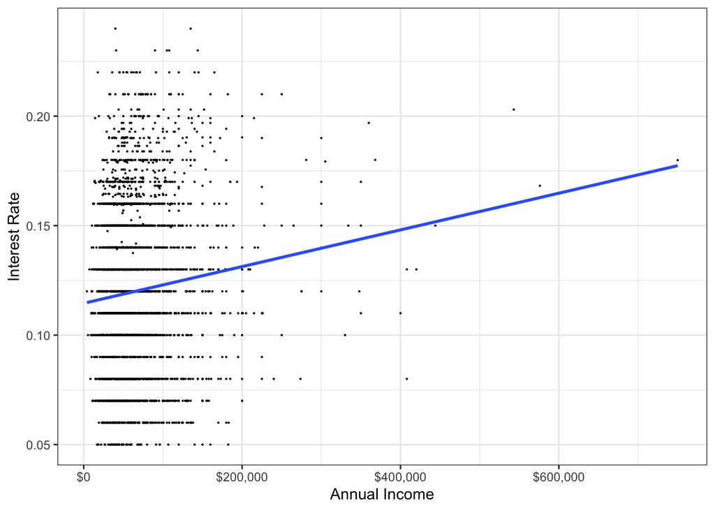

```r
# Produce a scatter plot of annual income against interest rate and add visually the line of best fit
ggplot(lc_clean[seq(1, nrow(lc_clean), 10), ] , aes(y=int_rate, x=annual_inc)) +
  geom_point(size=0.1)+
  geom_smooth(method="lm", se=0) +
  scale_x_continuous(label=scales::dollar)+
  labs(y="Interest Rate", x="Annual Income")+
  theme_bw()
```

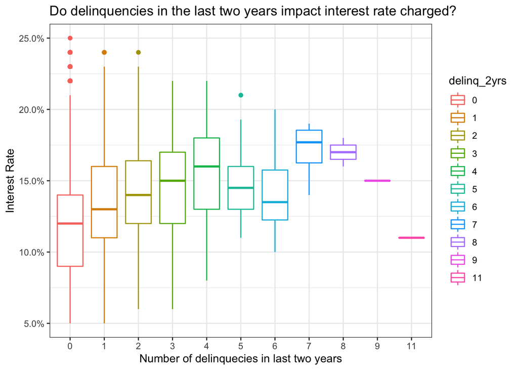

```r
# In the same axes, produce box plots of the interest rate for every value of delinquencies
ggplot(lc_clean , aes(y=int_rate, x=delinq_2yrs, colour= delinq_2yrs)) +
  geom_boxplot()+
  # geom_jitter()+
  theme_bw()+
   scale_y_continuous(labels=scales::percent)+
  theme(legend.position = "none")+
  labs(
    title = "Do delinquencies in the last two years impact interest rate charged?",
    x= "Number of delinquecies in last two years", y="Interest Rate"
  )+
  theme_bw()
```

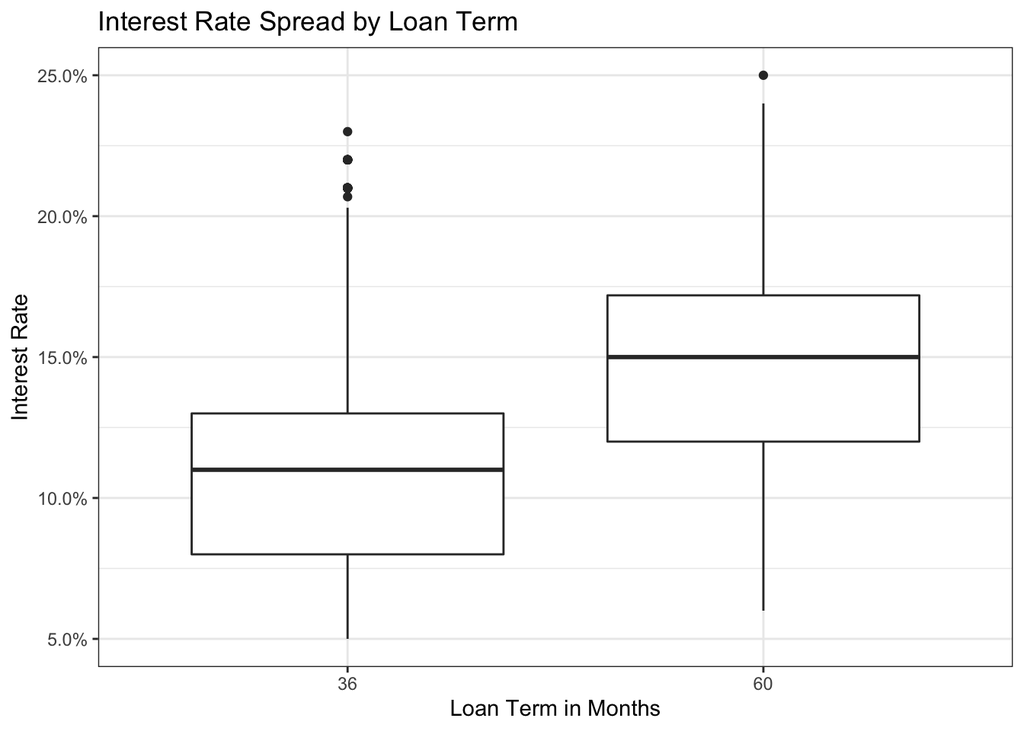

```r
#Create our own ones as well

#loan period vs interest rate
ggplot(lc_clean, aes(x=term, y = int_rate))+
  geom_boxplot()+
  labs(title="Interest Rate Spread by Loan Term",
       x="Loan Term in Months",
       y="Interest Rate")+
  scale_y_continuous(labels=scales::percent)+
  theme_bw()
```

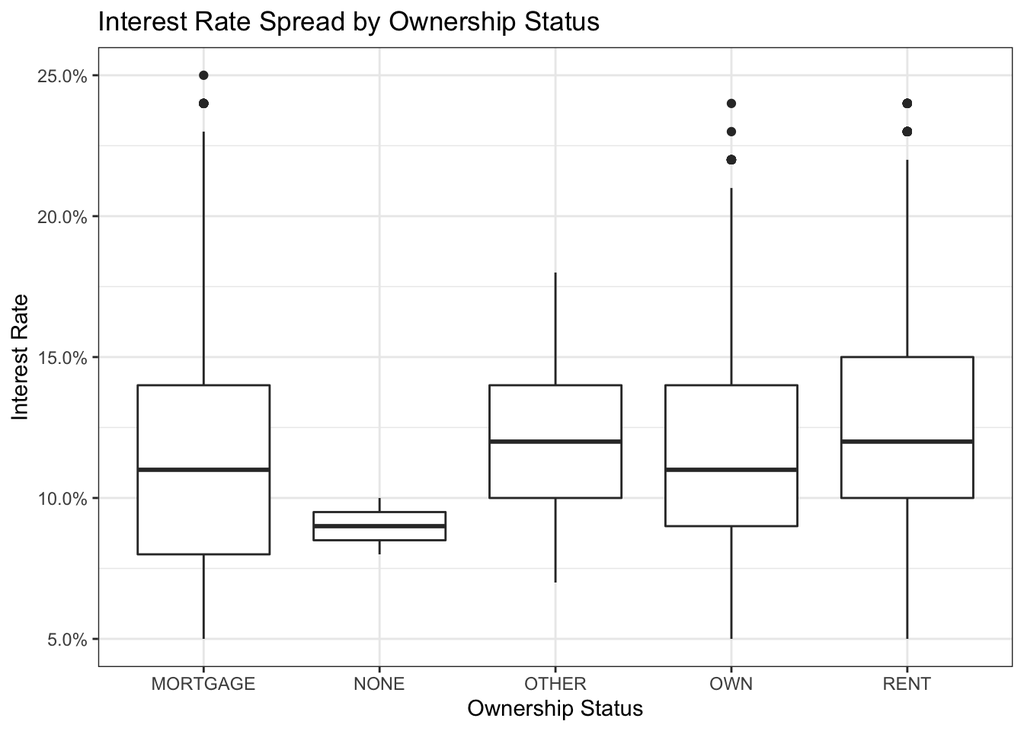

```r
#home ownership vs interest rate
ggplot(lc_clean, aes(x=home_ownership, y = int_rate))+
  geom_boxplot()+
  labs(title="Interest Rate Spread by Ownership Status",
       x="Ownership Status",
       y="Interest Rate")+
  scale_y_continuous(labels=scales::percent)+
  theme_bw()
```

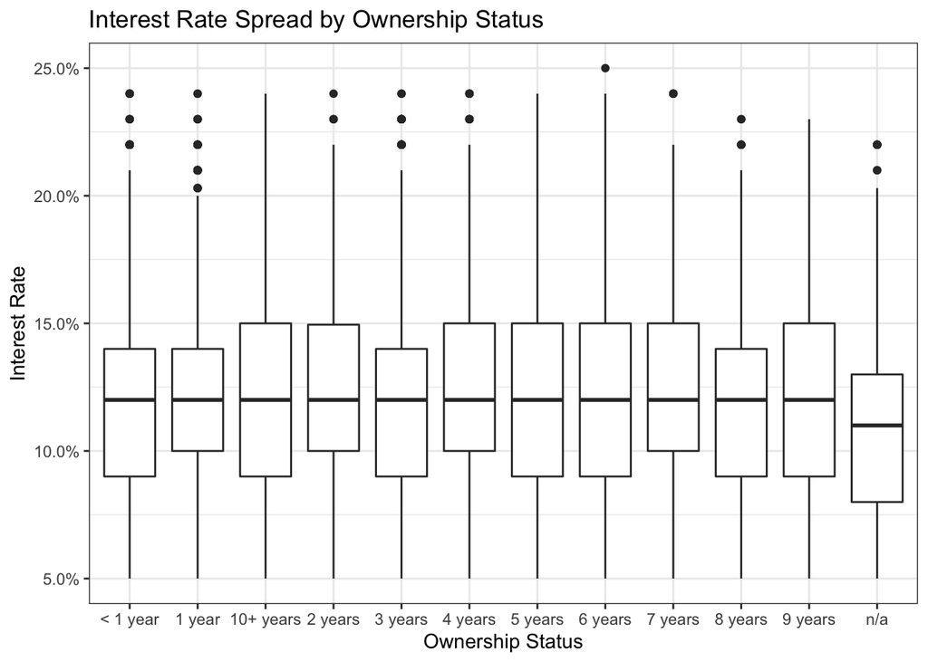

```r
#Employment Length vs Interest
ggplot(lc_clean, aes(x=emp_length, y = int_rate))+
  geom_boxplot()+
  labs(title="Interest Rate Spread by Ownership Status",
       x="Ownership Status",
       y="Interest Rate")+
  scale_y_continuous(labels=scales::percent)+
  theme_bw()
```

# Estimate simple linear regression models

We start with a simple but quite powerful model.

```r
#Use the lm command to estimate a regression model with the following variables "loan_amnt",  "term", "dti", "annual_inc", and "grade"

model1<-lm( int_rate ~ loan_amnt+ term+ dti+ annual_inc+ grade, data = lc_clean
  )
summary(model1) # noticed that annual income has a p value of over 0.05
```

```
##
## Call:
## lm(formula = int_rate ~ loan_amnt + term + dti + annual_inc +
##     grade, data = lc_clean)
##
## Residuals:
##       Min        1Q    Median        3Q       Max
## -0.118827 -0.007035 -0.000342  0.006828  0.035081
##
## Coefficients:
##               Estimate Std. Error t value Pr(>|t|)
## (Intercept)  7.169e-02  1.689e-04 424.363  < 2e-16 ***
## loan_amnt    1.475e-07  8.284e-09  17.809  < 2e-16 ***
## term60       3.608e-03  1.419e-04  25.431  < 2e-16 ***
## dti          4.328e-05  8.269e-06   5.234 1.66e-07 ***
## annual_inc  -9.734e-10  9.283e-10  -1.049    0.294
## gradeB       3.554e-02  1.492e-04 238.248  < 2e-16 ***
## gradeC       6.016e-02  1.658e-04 362.783  < 2e-16 ***
## gradeD       8.172e-02  1.906e-04 428.746  < 2e-16 ***
## gradeE       9.999e-02  2.483e-04 402.660  < 2e-16 ***
## gradeF       1.195e-01  3.673e-04 325.408  < 2e-16 ***
## gradeG       1.355e-01  6.208e-04 218.245  < 2e-16 ***
## ---
## Signif. codes:  0 '***' 0.001 '**' 0.01 '*' 0.05 '.' 0.1 ' ' 1
##
## Residual standard error: 0.01056 on 37858 degrees of freedom
## Multiple R-squared:  0.9198, Adjusted R-squared:  0.9197
## F-statistic: 4.34e+04 on 10 and 37858 DF,  p-value: < 2.2e-16
```

# Feature Engineering

Let’s build progressively more complex models with more features.

```r
#Add to the previous model an interaction between loan amount and grade. Use the "var1*var2" notation to define an interaction term in the linear regression model. This will add the interaction and the individual variables to the model.
model2 <-lm( int_rate ~ loan_amnt*grade+ term+ dti+ annual_inc, data = lc_clean
  )

summary(model2)
```

```
##
## Call:
## lm(formula = int_rate ~ loan_amnt * grade + term + dti + annual_inc,
##     data = lc_clean)
##
## Residuals:
##       Min        1Q    Median        3Q       Max
## -0.119807 -0.007230 -0.000057  0.006588  0.037460
##
## Coefficients:
##                    Estimate Std. Error t value Pr(>|t|)
## (Intercept)       7.171e-02  2.345e-04 305.762  < 2e-16 ***
## loan_amnt         1.528e-07  2.028e-08   7.537 4.91e-14 ***
## gradeB            3.623e-02  2.732e-04 132.619  < 2e-16 ***
## gradeC            6.198e-02  2.988e-04 207.452  < 2e-16 ***
## gradeD            8.082e-02  3.483e-04 232.034  < 2e-16 ***
## gradeE            9.633e-02  4.625e-04 208.293  < 2e-16 ***
## gradeF            1.143e-01  7.735e-04 147.699  < 2e-16 ***
## gradeG            1.327e-01  1.551e-03  85.580  < 2e-16 ***
## term60            3.793e-03  1.424e-04  26.636  < 2e-16 ***
## dti               3.836e-05  8.250e-06   4.649 3.34e-06 ***
## annual_inc       -1.224e-09  9.249e-10  -1.324  0.18564
## loan_amnt:gradeB -6.617e-08  2.441e-08  -2.710  0.00673 **
## loan_amnt:gradeC -1.704e-07  2.621e-08  -6.500 8.14e-11 ***
## loan_amnt:gradeD  6.703e-08  2.798e-08   2.395  0.01662 *
## loan_amnt:gradeE  2.209e-07  3.016e-08   7.323 2.47e-13 ***
## loan_amnt:gradeF  2.779e-07  4.136e-08   6.720 1.85e-11 ***
## loan_amnt:gradeG  1.265e-07  7.260e-08   1.743  0.08140 .
## ---
## Signif. codes:  0 '***' 0.001 '**' 0.01 '*' 0.05 '.' 0.1 ' ' 1
##
## Residual standard error: 0.01052 on 37852 degrees of freedom
## Multiple R-squared:  0.9204, Adjusted R-squared:  0.9204
## F-statistic: 2.735e+04 on 16 and 37852 DF,  p-value: < 2.2e-16
```

```r
#Add to the model the square and the cube of annual income. Use the poly(var_name,3) command as a variable in the linear regression model.
model3 <- lm( int_rate ~ loan_amnt*grade+ term+ dti+poly(annual_inc,3), data = lc_clean
  )
summary(model3) # makes no difference
```

```
##
## Call:
## lm(formula = int_rate ~ loan_amnt * grade + term + dti + poly(annual_inc,
##     3), data = lc_clean)
##
## Residuals:
##       Min        1Q    Median        3Q       Max
## -0.119814 -0.007238 -0.000065  0.006594  0.037471
##
## Coefficients:
##                        Estimate Std. Error t value Pr(>|t|)
## (Intercept)           7.161e-02  2.279e-04 314.200  < 2e-16 ***
## loan_amnt             1.556e-07  2.047e-08   7.600 3.03e-14 ***
## gradeB                3.623e-02  2.732e-04 132.611  < 2e-16 ***
## gradeC                6.198e-02  2.988e-04 207.398  < 2e-16 ***
## gradeD                8.081e-02  3.483e-04 231.999  < 2e-16 ***
## gradeE                9.633e-02  4.625e-04 208.283  < 2e-16 ***
## gradeF                1.143e-01  7.736e-04 147.695  < 2e-16 ***
## gradeG                1.327e-01  1.551e-03  85.573  < 2e-16 ***
## term60                3.786e-03  1.426e-04  26.546  < 2e-16 ***
## dti                   3.761e-05  8.294e-06   4.535 5.79e-06 ***
## poly(annual_inc, 3)1 -1.589e-02  1.117e-02  -1.423   0.1549
## poly(annual_inc, 3)2  6.296e-03  1.086e-02   0.580   0.5621
## poly(annual_inc, 3)3 -8.981e-03  1.084e-02  -0.828   0.4076
## loan_amnt:gradeB     -6.633e-08  2.442e-08  -2.717   0.0066 **
## loan_amnt:gradeC     -1.703e-07  2.621e-08  -6.498 8.23e-11 ***
## loan_amnt:gradeD      6.709e-08  2.798e-08   2.398   0.0165 *
## loan_amnt:gradeE      2.209e-07  3.016e-08   7.324 2.45e-13 ***
## loan_amnt:gradeF      2.780e-07  4.136e-08   6.722 1.82e-11 ***
## loan_amnt:gradeG      1.270e-07  7.260e-08   1.750   0.0801 .
## ---
## Signif. codes:  0 '***' 0.001 '**' 0.01 '*' 0.05 '.' 0.1 ' ' 1
##
## Residual standard error: 0.01052 on 37850 degrees of freedom
## Multiple R-squared:  0.9204, Adjusted R-squared:  0.9204
## F-statistic: 2.431e+04 on 18 and 37850 DF,  p-value: < 2.2e-16
```

```r
#Continuing with the previous model, instead of annual income as a continuous variable break it down into quartiles and use quartile dummy variables. You can do this with the following command.

lc_clean2 <- lc_clean %>%
  mutate(quartiles_annual_inc = as.factor(ntile(annual_inc, 4)))

model4 <-lm( int_rate ~ loan_amnt*grade+ term+ dti+quartiles_annual_inc, data = lc_clean2
  )
summary(model4)  # still makes no difference
```

```
##
## Call:
## lm(formula = int_rate ~ loan_amnt * grade + term + dti + quartiles_annual_inc,
##     data = lc_clean2)
##
## Residuals:
##       Min        1Q    Median        3Q       Max
## -0.119767 -0.007203 -0.000064  0.006596  0.037581
##
## Coefficients:
##                         Estimate Std. Error t value Pr(>|t|)
## (Intercept)            7.187e-02  2.414e-04 297.700  < 2e-16 ***
## loan_amnt              1.615e-07  2.048e-08   7.889 3.13e-15 ***
## gradeB                 3.622e-02  2.733e-04 132.524  < 2e-16 ***
## gradeC                 6.196e-02  2.989e-04 207.272  < 2e-16 ***
## gradeD                 8.079e-02  3.484e-04 231.877  < 2e-16 ***
## gradeE                 9.632e-02  4.625e-04 208.273  < 2e-16 ***
## gradeF                 1.143e-01  7.735e-04 147.723  < 2e-16 ***
## gradeG                 1.327e-01  1.551e-03  85.570  < 2e-16 ***
## term60                 3.781e-03  1.425e-04  26.532  < 2e-16 ***
## dti                    3.672e-05  8.259e-06   4.446 8.78e-06 ***
## quartiles_annual_inc2 -2.619e-04  1.548e-04  -1.692  0.09068 .
## quartiles_annual_inc3 -3.992e-04  1.590e-04  -2.510  0.01208 *
## quartiles_annual_inc4 -5.382e-04  1.692e-04  -3.181  0.00147 **
## loan_amnt:gradeB      -6.638e-08  2.441e-08  -2.719  0.00655 **
## loan_amnt:gradeC      -1.699e-07  2.621e-08  -6.483 9.10e-11 ***
## loan_amnt:gradeD       6.770e-08  2.798e-08   2.419  0.01555 *
## loan_amnt:gradeE       2.203e-07  3.016e-08   7.304 2.85e-13 ***
## loan_amnt:gradeF       2.766e-07  4.136e-08   6.687 2.30e-11 ***
## loan_amnt:gradeG       1.267e-07  7.259e-08   1.746  0.08089 .
## ---
## Signif. codes:  0 '***' 0.001 '**' 0.01 '*' 0.05 '.' 0.1 ' ' 1
##
## Residual standard error: 0.01052 on 37850 degrees of freedom
## Multiple R-squared:  0.9204, Adjusted R-squared:  0.9204
## F-statistic: 2.432e+04 on 18 and 37850 DF,  p-value: < 2.2e-16
```

```r
#Compare the performance of these four models using the anova command
anova(model1, model2, model3, model4
      )
```

| Res.Df | RSS | Df | Sum of Sq | F | Pr(>F) |
| --- | --- | --- | --- | --- | --- |
| 3.79e+04 | 4.22 |  |  |  |  |
| 3.79e+04 | 4.19 | 6 | 0.0332 | 50 | 1.64e-61 |
| 3.78e+04 | 4.19 | 2 | 0.000107 | 0.484 | 0.616 |
| 3.78e+04 | 4.19 | 0 | 0.000915 |  |  |

## Q3. Answer the following questions

# Out of sample testing

Let’s check the predictive accuracy of model2 by holding out a subset of the data to use as testing. This method is sometimes refered to as the hold-out method for out-of-sample testing.

```r
#split the data in dataframe called "testing" and another one called  "training". The "training" dataframe should have 80% of the data and the "testing" dataframe 20%.
set.seed(176823769)
train_test_split <- initial_split(lc_clean2, prop=0.8) # splitting dataset
lc_clean_train<- training(train_test_split)
lc_clean_test<- testing(train_test_split)


#Fit model2 on the training set
model2_training<-lm(int_rate ~ loan_amnt + term+ dti + annual_inc + grade +grade:loan_amnt, data=lc_clean_train)
summary(model2_training)
```

```
##
## Call:
## lm(formula = int_rate ~ loan_amnt + term + dti + annual_inc +
##     grade + grade:loan_amnt, data = lc_clean_train)
##
## Residuals:
##       Min        1Q    Median        3Q       Max
## -0.119766 -0.007211 -0.000044  0.006588  0.037641
##
## Coefficients:
##                    Estimate Std. Error t value Pr(>|t|)
## (Intercept)       7.162e-02  2.637e-04 271.568  < 2e-16 ***
## loan_amnt         1.586e-07  2.251e-08   7.045 1.89e-12 ***
## term60            3.772e-03  1.592e-04  23.691  < 2e-16 ***
## dti               4.069e-05  9.232e-06   4.407 1.05e-05 ***
## annual_inc       -8.114e-10  1.195e-09  -0.679  0.49710
## gradeB            3.622e-02  3.040e-04 119.160  < 2e-16 ***
## gradeC            6.197e-02  3.329e-04 186.186  < 2e-16 ***
## gradeD            8.088e-02  3.870e-04 209.006  < 2e-16 ***
## gradeE            9.605e-02  5.146e-04 186.643  < 2e-16 ***
## gradeF            1.140e-01  8.721e-04 130.704  < 2e-16 ***
## gradeG            1.338e-01  1.747e-03  76.571  < 2e-16 ***
## loan_amnt:gradeB -7.332e-08  2.717e-08  -2.699  0.00696 **
## loan_amnt:gradeC -1.755e-07  2.923e-08  -6.004 1.95e-09 ***
## loan_amnt:gradeD  6.792e-08  3.114e-08   2.181  0.02916 *
## loan_amnt:gradeE  2.292e-07  3.346e-08   6.851 7.49e-12 ***
## loan_amnt:gradeF  2.973e-07  4.619e-08   6.436 1.24e-10 ***
## loan_amnt:gradeG  7.974e-08  8.208e-08   0.971  0.33132
## ---
## Signif. codes:  0 '***' 0.001 '**' 0.01 '*' 0.05 '.' 0.1 ' ' 1
##
## Residual standard error: 0.01049 on 30279 degrees of freedom
## Multiple R-squared:  0.9209, Adjusted R-squared:  0.9208
## F-statistic: 2.203e+04 on 16 and 30279 DF,  p-value: < 2.2e-16
```

```r
#Calculate the RMSE of the model in the training set (in sample)
rmse_training<-sqrt(mean((residuals(model2_training))^2))
#USe the model to make predictions out of sample in the testing set
pred<-predict(model2_training,lc_clean_test)
#Calculate the RMSE of the model in the testing set (out of sample)
rmse_testing<- RMSE(pred,lc_clean_test$int_rate)

rmse_training
```

```
## [1] 0.01048876
```

```r
rmse_testing
```

```
## [1] 0.01061575
```

## Q4. How much does the predictive accuracy of model 2 deteriorate when we move from in sample to out of sample testing? Is this sensitive to the random seed chosen? Is there any evidence of overfitting?

> The predictive accuracy of model 2 does not much deteriorate when we move from in sample to out of sample testing. For purpose of checking it we compare the rmse_training to rmse_testing (0.0104 compared to 0.01061). We tried to check if the model is sensitive for the multiple random seed choices and we discovered that the model is not much sensitive (rmse is still a factor of e-2). There isn’t any evidence of overfitting.

# k-fold cross validation

We can also do out of sample testing using the method of k-fold cross validation. Using the caret package this is easy.

```r
#the method "cv" stands for cross validation. We re going to create 10 folds.

control <- trainControl (
    method="cv",
    number=10,
    verboseIter=TRUE) #by setting this to true the model will report its progress after each estimation

#we are going to train the model and report the results using k-fold cross validation
plsFit<-train(
    int_rate ~ loan_amnt + term+ dti + annual_inc + grade +grade:loan_amnt ,
    lc_clean,
   method = "lm",
    trControl = control
   )
summary(plsFit)
```

```
##
## Call:
## lm(formula = .outcome ~ ., data = dat)
##
## Residuals:
##       Min        1Q    Median        3Q       Max
## -0.119807 -0.007230 -0.000057  0.006588  0.037460
##
## Coefficients:
##                      Estimate Std. Error t value Pr(>|t|)
## (Intercept)         7.171e-02  2.345e-04 305.762  < 2e-16 ***
## loan_amnt           1.528e-07  2.028e-08   7.537 4.91e-14 ***
## term60              3.793e-03  1.424e-04  26.636  < 2e-16 ***
## dti                 3.836e-05  8.250e-06   4.649 3.34e-06 ***
## annual_inc         -1.224e-09  9.249e-10  -1.324  0.18564
## gradeB              3.623e-02  2.732e-04 132.619  < 2e-16 ***
## gradeC              6.198e-02  2.988e-04 207.452  < 2e-16 ***
## gradeD              8.082e-02  3.483e-04 232.034  < 2e-16 ***
## gradeE              9.633e-02  4.625e-04 208.293  < 2e-16 ***
## gradeF              1.143e-01  7.735e-04 147.699  < 2e-16 ***
## gradeG              1.327e-01  1.551e-03  85.580  < 2e-16 ***
## `loan_amnt:gradeB` -6.617e-08  2.441e-08  -2.710  0.00673 **
## `loan_amnt:gradeC` -1.704e-07  2.621e-08  -6.500 8.14e-11 ***
## `loan_amnt:gradeD`  6.703e-08  2.798e-08   2.395  0.01662 *
## `loan_amnt:gradeE`  2.209e-07  3.016e-08   7.323 2.47e-13 ***
## `loan_amnt:gradeF`  2.779e-07  4.136e-08   6.720 1.85e-11 ***
## `loan_amnt:gradeG`  1.265e-07  7.260e-08   1.743  0.08140 .
## ---
## Signif. codes:  0 '***' 0.001 '**' 0.01 '*' 0.05 '.' 0.1 ' ' 1
##
## Residual standard error: 0.01052 on 37852 degrees of freedom
## Multiple R-squared:  0.9204, Adjusted R-squared:  0.9204
## F-statistic: 2.735e+04 on 16 and 37852 DF,  p-value: < 2.2e-16
```

## Q5. Compare the out-of-sample RMSE of 10-fold cross validation and the hold-out method. Are they different? Which do you think is more reliable? Are there any drawbacks to the k-fold cross validation method compared to the hold-out method?

# Sample size estimation and learning curves

We can use the hold out method for out-of-sample testing to check if we have a sufficiently large sample to estimate the model reliably. The idea is to set aside some of the data as a testing set. From the remaining data draw progressively larger training sets and check how the performance of the model on the testing set changes. If the performance no longer improves with larger datasets we know we have a large enough sample. The code below does this. Examine it and run it with different random seeds.

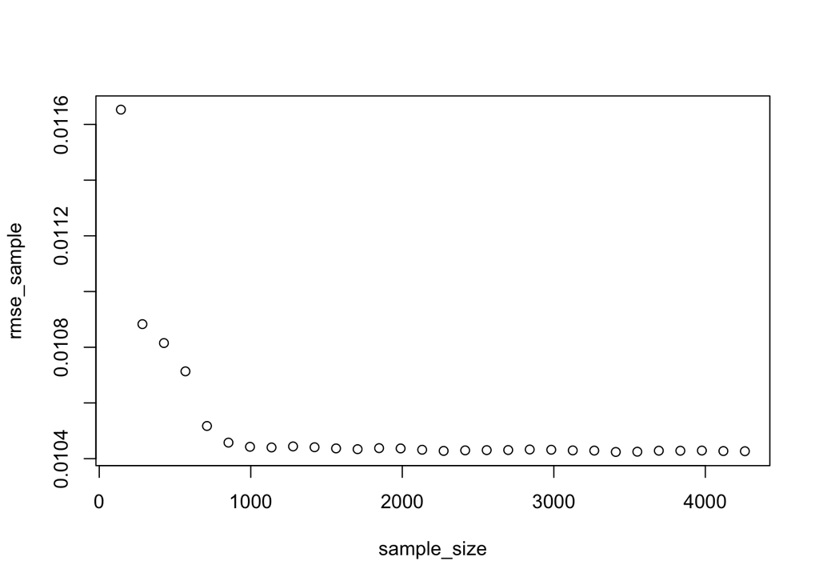

```r
#select a testing dataset (25% of all data)
set.seed(12)

train_test_split <- initial_split(lc_clean, prop = 0.75)
remaining <- training(train_test_split)
testing <- testing(train_test_split)

#We are now going to run 30 models starting from a tiny training set drawn from the training data and progressively increasing its size. The testing set remains the same in all iterations.

#initiating the model by setting some parameters to zero
rmse_sample <- 0
sample_size<-0
Rsq_sample<-0

for(i in 1:30) {
#from the remaining dataset select a smaller subset to training the data
set.seed(100)
sample

  learning_split <- initial_split(remaining, prop = i/200)
  training <- training(learning_split)
  sample_size[i]=nrow(training)

  #traing the model on the small dataset
  model3<-lm(int_rate ~ loan_amnt + term+ dti + annual_inc + grade + grade:loan_amnt, training)
  #test the performance of the model on the large testing dataset. This stays fixed for all iterations.
  pred<-predict(model3,testing)
  rmse_sample[i]<-RMSE(pred,testing$int_rate)
  Rsq_sample[i]<-R2(pred,testing$int_rate)
}
plot(sample_size,rmse_sample)
```

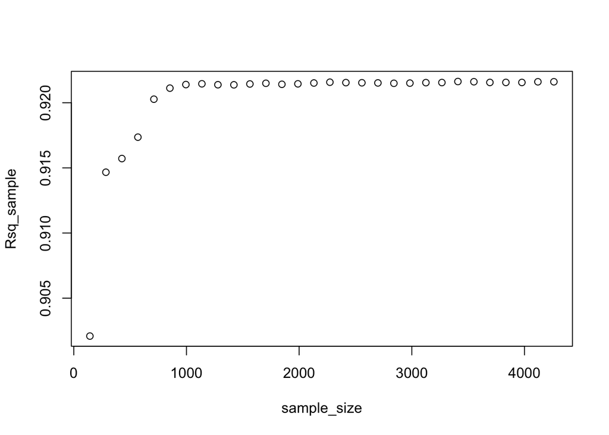

```r
plot(sample_size,Rsq_sample)
```

## Q6. Using the learning curves above, approximately how large of a sample size would we need to estimate model 3 reliably? Once we reach this sample size, if we want to reduce the prediction error further what options do we have?

> Answer here: After analysing the graphs above, we noticed that the sample size that would estimate model 3 reliably is 1500. Once we reach this sample size, we can still try to reduce the prediction error by regularization or using the k-fold cross validation method.

# Regularization using LASSO regression

If we are in the region of the learning curve where we do not have enough data, one option is to use a regularization method such as LASSO.

Let’s try to estimate large and complicated model (many interactions and polynomials) on a small training dataset using OLS regression and hold-out validation method.

```r
#split the data in testing and training. The training test is really small.
set.seed(1234)
train_test_split <- initial_split(lc_clean, prop = 0.01)
training <- training(train_test_split)
testing <- testing(train_test_split)

model_lm<-lm(int_rate ~ poly(loan_amnt,3) + term+ dti + annual_inc + grade +grade:poly(loan_amnt,3):term +poly(loan_amnt,3):term +grade:term, training)
predictions <- predict(model_lm,testing)
# Model prediction performance
data.frame(
  RMSE = RMSE(predictions, testing$int_rate),
  Rsquare = R2(predictions, testing$int_rate)
)
```

| RMSE | Rsquare |
| --- | --- |
| 0.0446 | 0.352 |

Not surprisingly this model does not perform well – as we knew form the learning curves we constructed for a simpler model we need a lot more data to estimate this model reliably. Try running it again with different seeds. The model’s performance tends to be sensitive to the choice of the training set.

```r
#we will look for the optimal lambda in this sequence (we will try 1000 different lambdas)
lambda_seq <- seq(0, 0.01, length = 1000)
#lasso regression using k-fold cross validation to select the best lambda

lasso <- train(
 int_rate ~ poly(loan_amnt,3) + term+ dti + annual_inc + grade +grade:poly(loan_amnt,3):term +poly(loan_amnt,3):term +grade:term,
 data = training,
 method = "glmnet",
  preProc = c("center", "scale"), #This option standardizes the data before running the LASSO regression
  trControl = control,
  tuneGrid = expand.grid(alpha = 1, lambda = lambda_seq) #alpha=1 specifies to run a LASSO regression. If alpha=0 the model would run ridge regression.
  )
# Model coefficients
coef(lasso$finalModel, lasso$bestTune$lambda)
```

```
## 58 x 1 sparse Matrix of class "dgCMatrix"
##                                               1
## (Intercept)                        1.185298e-01
## poly(loan_amnt, 3)1                .
## poly(loan_amnt, 3)2                .
## poly(loan_amnt, 3)3                .
## term60                             7.098602e-04
## dti                                .
## annual_inc                         .
## gradeB                             1.415886e-02
## gradeC                             2.280581e-02
## gradeD                             2.431974e-02
## gradeE                             2.278486e-02
## gradeF                             1.692347e-02
## gradeG                             7.860209e-03
## poly(loan_amnt, 3)1:term60         1.784368e-03
## poly(loan_amnt, 3)2:term60         .
## poly(loan_amnt, 3)3:term60         .
## term60:gradeB                      .
## term60:gradeC                      .
## term60:gradeD                      1.221352e-04
## term60:gradeE                      3.431031e-03
## term60:gradeF                      1.857156e-04
## term60:gradeG                      3.261629e-04
## poly(loan_amnt, 3)1:term36:gradeB  .
## poly(loan_amnt, 3)2:term36:gradeB  .
## poly(loan_amnt, 3)3:term36:gradeB  .
## poly(loan_amnt, 3)1:term60:gradeB  .
## poly(loan_amnt, 3)2:term60:gradeB  .
## poly(loan_amnt, 3)3:term60:gradeB  .
## poly(loan_amnt, 3)1:term36:gradeC -9.385425e-05
## poly(loan_amnt, 3)2:term36:gradeC  .
## poly(loan_amnt, 3)3:term36:gradeC  .
## poly(loan_amnt, 3)1:term60:gradeC -3.097033e-04
## poly(loan_amnt, 3)2:term60:gradeC  .
## poly(loan_amnt, 3)3:term60:gradeC  .
## poly(loan_amnt, 3)1:term36:gradeD -2.006746e-04
## poly(loan_amnt, 3)2:term36:gradeD  .
## poly(loan_amnt, 3)3:term36:gradeD  .
## poly(loan_amnt, 3)1:term60:gradeD  .
## poly(loan_amnt, 3)2:term60:gradeD  .
## poly(loan_amnt, 3)3:term60:gradeD  .
## poly(loan_amnt, 3)1:term36:gradeE  .
## poly(loan_amnt, 3)2:term36:gradeE  1.563861e-04
## poly(loan_amnt, 3)3:term36:gradeE -2.895880e-04
## poly(loan_amnt, 3)1:term60:gradeE  1.996920e-04
## poly(loan_amnt, 3)2:term60:gradeE  .
## poly(loan_amnt, 3)3:term60:gradeE  1.773125e-04
## poly(loan_amnt, 3)1:term36:gradeF  .
## poly(loan_amnt, 3)2:term36:gradeF  .
## poly(loan_amnt, 3)3:term36:gradeF  .
## poly(loan_amnt, 3)1:term60:gradeF  7.979355e-05
## poly(loan_amnt, 3)2:term60:gradeF  .
## poly(loan_amnt, 3)3:term60:gradeF  .
## poly(loan_amnt, 3)1:term36:gradeG  .
## poly(loan_amnt, 3)2:term36:gradeG  .
## poly(loan_amnt, 3)3:term36:gradeG  .
## poly(loan_amnt, 3)1:term60:gradeG  3.954958e-06
## poly(loan_amnt, 3)2:term60:gradeG  5.059345e-08
## poly(loan_amnt, 3)3:term60:gradeG  .
```

```r
#Best lambda
lasso$bestTune$lambda
```

```
## [1] 0.0005805806
```

```r
# Count of how many coefficients are greater than zero and how many are equal to zero
sum(coef(lasso$finalModel, lasso$bestTune$lambda)!=0)
```

```
## [1] 23
```

```r
sum(coef(lasso$finalModel, lasso$bestTune$lambda)==0)
```

```
## [1] 35
```

```r
# Make predictions
predictions <- predict(lasso,testing)

# Model prediction performance
data.frame(
  RMSE = RMSE(predictions, testing$int_rate),
  Rsquare = R2(predictions, testing$int_rate)
)
```

| RMSE | Rsquare |
| --- | --- |
| 0.0109 | 0.917 |

# Using Time Information

Let’s try to further improve the model’s predictive performance. So far we have not used any time series information. Effectively, all things being equal, our prediction for the interest rate of a loan given in 2009 would be the same as that of a loan given in 2011. Is this a good assumption?

First, investigate graphically whether there are any time trends in the interest rates. (Note that the variable “issue_d” only has information on the month the loan was awarded but not the exact date.) Can you use this information to further improve the forecasting accuracy of your model? Try controlling for time in a linear fashion (i.e., a linear time trend) and controlling for time as quarter dummies (this is a method to capture non-linear effects of time – we assume that the impact of time doesn’t change within a quarter but it can chance from quarter to quarter). Finally, check if time affect loans of different grades differently.

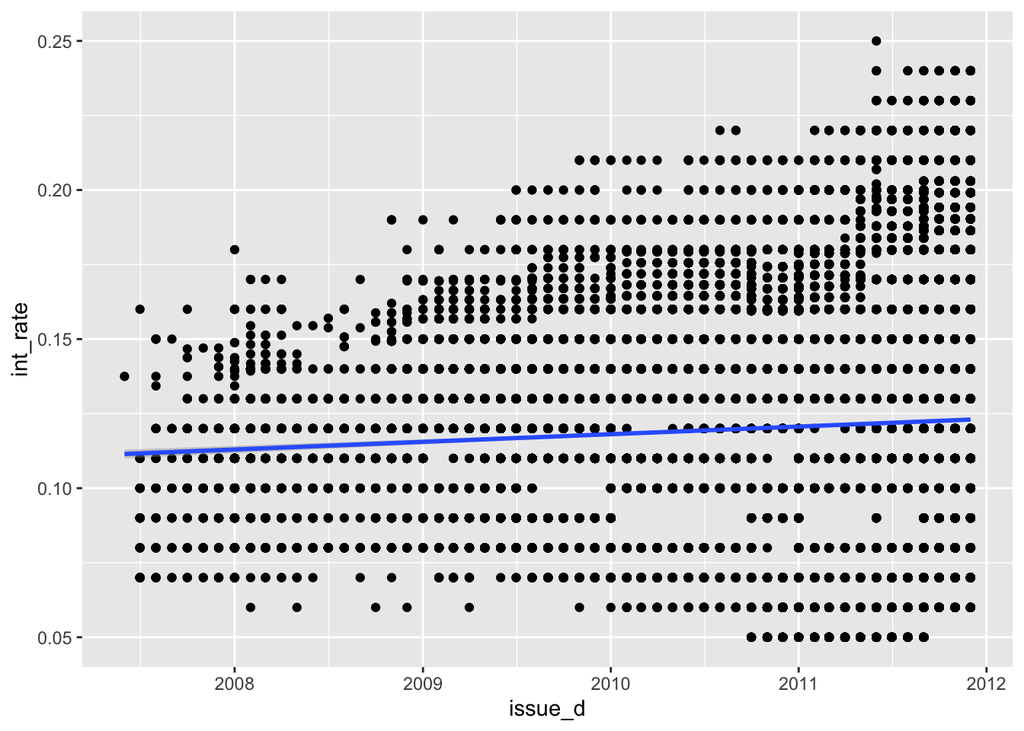

```r
#linear time trend (add code below)

ggplot(lc_clean, aes(x=issue_d,y=int_rate))+
  geom_point()+
  geom_smooth(method="lm")
```

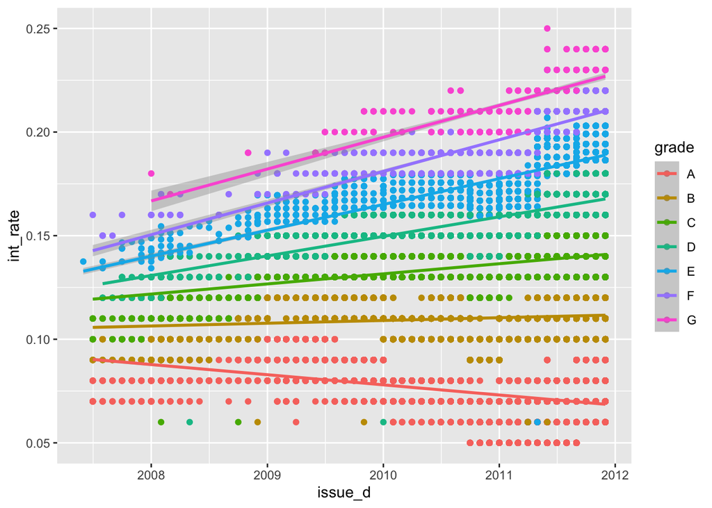

```r
#linear time trend by grade (add code below)
ggplot(lc_clean, aes(x=issue_d,y=int_rate, colour=grade))+
  geom_point()+
  geom_smooth(method="lm")
```

```r
glimpse(lc_clean2)
```

```
## Rows: 37,869
## Columns: 21
## $ int_rate             <dbl> 0.05, 0.05, 0.05, 0.05, 0.05, 0.05, 0.05, 0.05, …
## $ loan_amnt            <dbl> 8000, 6000, 6500, 8000, 5500, 6000, 10200, 15000…
## $ dti                  <dbl> 2.11, 5.73, 17.68, 22.71, 5.75, 21.92, 18.62, 9.…
## $ delinq_2yrs          <fct> 0, 0, 0, 0, 0, 0, 0, 0, 0, 0, 0, 0, 0, 0, 0, 0, …
## $ annual_inc           <dbl> 50000, 52800, 35352, 79200, 240000, 89000, 11000…
## $ grade                <chr> "A", "A", "A", "A", "A", "A", "A", "A", "A", "A"…
## $ emp_length           <fct> 5 years, < 1 year, n/a, n/a, 10+ years, 2 years,…
## $ home_ownership       <chr> "MORTGAGE", "MORTGAGE", "MORTGAGE", "MORTGAGE", …
## $ verification_status  <chr> "Verified", "Source Verified", "Not Verified", "…
## $ issue_d              <date> 2011-09-01, 2011-09-01, 2011-09-01, 2011-09-01,…
## $ zip_code             <chr> "977xx", "228xx", "864xx", "322xx", "278xx", "76…
## $ addr_state           <chr> "OR", "VA", "AZ", "FL", "NC", "TX", "CT", "WA", …
## $ loan_status          <chr> "Fully Paid", "Charged Off", "Fully Paid", "Full…
## $ desc                 <chr> "Borrower added on 09/08/11 > Consolidating debt…
## $ purpose              <chr> "debt_consolidation", "vacation", "credit_card",…
## $ title                <chr> "Credit Card Payoff $8K", "bad choice", "Credit …
## $ term                 <fct> 36, 36, 36, 36, 36, 36, 36, 36, 36, 36, 36, 36, …
## $ term_months          <dbl> 36, 36, 36, 36, 36, 36, 36, 36, 36, 36, 36, 36, …
## $ installment          <dbl> 241.28, 180.96, 196.04, 241.28, 165.88, 180.96, …
## $ emp_title            <chr> NA, "coral graphics", NA, "Honeywell", "O T Plus…
## $ quartiles_annual_inc <fct> 2, 2, 1, 3, 4, 4, 4, 4, 2, 2, 4, 3, 3, 2, 1, 3, …
```

```r
#Train models using OLS regression and k-fold cross-validation
#The first model has some explanatory variables and a linear time trend

time1<-train(
  int_rate ~ loan_amnt*grade+ term+ dti + issue_d,#fill your variables here "+ issue_d"
  lc_clean,
  method = "lm",
  trControl = control)
summary(time1) # seems like dti is corrolated with issue_d (maybe lots of people defaulted because of the crisis)
```

```
##
## Call:
## lm(formula = .outcome ~ ., data = dat)
##
## Residuals:
##       Min        1Q    Median        3Q       Max
## -0.119019 -0.006587 -0.000749  0.006951  0.036179
##
## Coefficients:
##                      Estimate Std. Error t value Pr(>|t|)
## (Intercept)        -2.511e-02  2.512e-03 -10.000  < 2e-16 ***
## loan_amnt           8.842e-08  1.984e-08   4.456 8.36e-06 ***
## gradeB              3.609e-02  2.680e-04 134.681  < 2e-16 ***
## gradeC              6.247e-02  2.933e-04 212.962  < 2e-16 ***
## gradeD              8.131e-02  3.418e-04 237.889  < 2e-16 ***
## gradeE              9.729e-02  4.542e-04 214.172  < 2e-16 ***
## gradeF              1.152e-01  7.591e-04 151.809  < 2e-16 ***
## gradeG              1.337e-01  1.521e-03  87.877  < 2e-16 ***
## term60              2.263e-03  1.451e-04  15.602  < 2e-16 ***
## dti                 1.204e-05  8.037e-06   1.499   0.1340
## issue_d             6.539e-06  1.691e-07  38.675  < 2e-16 ***
## `loan_amnt:gradeB` -1.286e-11  2.401e-08  -0.001   0.9996
## `loan_amnt:gradeC` -1.207e-07  2.574e-08  -4.689 2.76e-06 ***
## `loan_amnt:gradeD`  1.138e-07  2.747e-08   4.143 3.43e-05 ***
## `loan_amnt:gradeE`  2.459e-07  2.959e-08   8.311  < 2e-16 ***
## `loan_amnt:gradeF`  3.012e-07  4.057e-08   7.424 1.16e-13 ***
## `loan_amnt:gradeG`  1.580e-07  7.120e-08   2.220   0.0265 *
## ---
## Signif. codes:  0 '***' 0.001 '**' 0.01 '*' 0.05 '.' 0.1 ' ' 1
##
## Residual standard error: 0.01031 on 37852 degrees of freedom
## Multiple R-squared:  0.9234, Adjusted R-squared:  0.9234
## F-statistic: 2.853e+04 on 16 and 37852 DF,  p-value: < 2.2e-16
```

```r
#The second model has a different linear time trend for each grade class
time2<-train(
    int_rate ~ loan_amnt*grade+ term+ dti + issue_d*grade, #fill your variables here
    lc_clean,
   method = "lm",
    trControl = control
   )
summary(time2)
```

```
##
## Call:
## lm(formula = .outcome ~ ., data = dat)
##
## Residuals:
##       Min        1Q    Median        3Q       Max
## -0.120428 -0.006609 -0.000147  0.006760  0.030757
##
## Coefficients:
##                      Estimate Std. Error t value Pr(>|t|)
## (Intercept)         2.859e-01  4.356e-03  65.621  < 2e-16 ***
## loan_amnt           3.033e-07  1.759e-08  17.239  < 2e-16 ***
## gradeB             -2.297e-01  5.808e-03 -39.552  < 2e-16 ***
## gradeC             -3.539e-01  6.179e-03 -57.274  < 2e-16 ***
## gradeD             -5.145e-01  7.198e-03 -71.474  < 2e-16 ***
## gradeE             -6.134e-01  9.905e-03 -61.926  < 2e-16 ***
## gradeF             -7.105e-01  1.612e-02 -44.082  < 2e-16 ***
## gradeG             -7.104e-01  3.314e-02 -21.434  < 2e-16 ***
## term60             -6.086e-04  1.301e-04  -4.676 2.94e-06 ***
## dti                 5.759e-05  7.064e-06   8.152 3.69e-16 ***
## issue_d            -1.443e-05  2.935e-07 -49.168  < 2e-16 ***
## `loan_amnt:gradeB` -1.558e-07  2.123e-08  -7.342 2.15e-13 ***
## `loan_amnt:gradeC` -3.237e-07  2.283e-08 -14.178  < 2e-16 ***
## `loan_amnt:gradeD` -1.783e-07  2.435e-08  -7.322 2.48e-13 ***
## `loan_amnt:gradeE` -1.725e-07  2.659e-08  -6.488 8.82e-11 ***
## `loan_amnt:gradeF` -1.862e-07  3.677e-08  -5.064 4.13e-07 ***
## `loan_amnt:gradeG` -2.963e-07  6.439e-08  -4.602 4.21e-06 ***
## `gradeB:issue_d`    1.790e-05  3.903e-07  45.860  < 2e-16 ***
## `gradeC:issue_d`    2.806e-05  4.165e-07  67.364  < 2e-16 ***
## `gradeD:issue_d`    4.018e-05  4.850e-07  82.852  < 2e-16 ***
## `gradeE:issue_d`    4.799e-05  6.680e-07  71.843  < 2e-16 ***
## `gradeF:issue_d`    5.573e-05  1.085e-06  51.348  < 2e-16 ***
## `gradeG:issue_d`    5.696e-05  2.230e-06  25.544  < 2e-16 ***
## ---
## Signif. codes:  0 '***' 0.001 '**' 0.01 '*' 0.05 '.' 0.1 ' ' 1
##
## Residual standard error: 0.009049 on 37846 degrees of freedom
## Multiple R-squared:  0.9411, Adjusted R-squared:  0.941
## F-statistic: 2.747e+04 on 22 and 37846 DF,  p-value: < 2.2e-16
```

```r
#Change the time trend to a quarter dummy variables.
#zoo::as.yearqrt() creates quarter dummies
lc_clean_quarter<-lc_clean %>%
  mutate(yq = as.factor(as.yearqtr(lc_clean$issue_d, format = "%Y-%m-%d")))



time3<-train(
    int_rate ~loan_amnt*grade+ term+ dti + yq ,#fill your variables here
    lc_clean_quarter,
     method = "lm",
    trControl = control
   )
summary(time3)
```

```
##
## Call:
## lm(formula = .outcome ~ ., data = dat)
##
## Residuals:
##       Min        1Q    Median        3Q       Max
## -0.115934 -0.005413 -0.000246  0.005794  0.037599
##
## Coefficients:
##                      Estimate Std. Error t value Pr(>|t|)
## (Intercept)         3.827e-02  9.076e-03   4.217 2.48e-05 ***
## loan_amnt           1.043e-07  1.750e-08   5.960 2.54e-09 ***
## gradeB              3.659e-02  2.358e-04 155.130  < 2e-16 ***
## gradeC              6.250e-02  2.583e-04 241.955  < 2e-16 ***
## gradeD              8.098e-02  3.009e-04 269.098  < 2e-16 ***
## gradeE              9.700e-02  3.999e-04 242.537  < 2e-16 ***
## gradeF              1.154e-01  6.678e-04 172.737  < 2e-16 ***
## gradeG              1.338e-01  1.338e-03 100.000  < 2e-16 ***
## term60              4.581e-03  1.308e-04  35.027  < 2e-16 ***
## dti                 5.894e-06  7.072e-06   0.833 0.404594
## `yq2007 Q3`         1.911e-02  9.135e-03   2.092 0.036420 *
## `yq2007 Q4`         1.469e-02  9.103e-03   1.614 0.106478
## `yq2008 Q1`         2.114e-02  9.082e-03   2.328 0.019928 *
## `yq2008 Q2`         2.275e-02  9.090e-03   2.503 0.012318 *
## `yq2008 Q3`         2.391e-02  9.100e-03   2.627 0.008608 **
## `yq2008 Q4`         3.183e-02  9.083e-03   3.504 0.000458 ***
## `yq2009 Q1`         3.601e-02  9.079e-03   3.967 7.30e-05 ***
## `yq2009 Q2`         3.786e-02  9.078e-03   4.171 3.04e-05 ***
## `yq2009 Q3`         3.939e-02  9.077e-03   4.340 1.43e-05 ***
## `yq2009 Q4`         3.965e-02  9.076e-03   4.369 1.25e-05 ***
## `yq2010 Q1`         3.463e-02  9.076e-03   3.815 0.000136 ***
## `yq2010 Q2`         3.338e-02  9.075e-03   3.678 0.000235 ***
## `yq2010 Q3`         3.447e-02  9.075e-03   3.798 0.000146 ***
## `yq2010 Q4`         2.575e-02  9.075e-03   2.837 0.004552 **
## `yq2011 Q1`         2.788e-02  9.075e-03   3.072 0.002128 **
## `yq2011 Q2`         3.304e-02  9.074e-03   3.641 0.000271 ***
## `yq2011 Q3`         3.544e-02  9.074e-03   3.905 9.42e-05 ***
## `yq2011 Q4`         4.168e-02  9.074e-03   4.593 4.39e-06 ***
## `loan_amnt:gradeB` -1.079e-07  2.117e-08  -5.098 3.45e-07 ***
## `loan_amnt:gradeC` -2.145e-07  2.271e-08  -9.446  < 2e-16 ***
## `loan_amnt:gradeD`  5.841e-08  2.422e-08   2.411 0.015896 *
## `loan_amnt:gradeE`  1.817e-07  2.609e-08   6.963 3.39e-12 ***
## `loan_amnt:gradeF`  2.266e-07  3.573e-08   6.343 2.28e-10 ***
## `loan_amnt:gradeG`  1.125e-07  6.264e-08   1.795 0.072595 .
## ---
## Signif. codes:  0 '***' 0.001 '**' 0.01 '*' 0.05 '.' 0.1 ' ' 1
##
## Residual standard error: 0.00907 on 37835 degrees of freedom
## Multiple R-squared:  0.9408, Adjusted R-squared:  0.9408
## F-statistic: 1.822e+04 on 33 and 37835 DF,  p-value: < 2.2e-16
```

```r
#We specify one quarter dummy variable for each grade. This is going to be a large model as there are 19 quarters x 7 grades = 133 quarter-grade dummies.
time4<-train(
    int_rate ~loan_amnt*grade+ term+ dti + yq*grade ,#fill your variables here
    lc_clean_quarter,
     method = "lm",
    trControl = control
   )
summary(time4)
```

```
##
## Call:
## lm(formula = .outcome ~ ., data = dat)
##
## Residuals:
##       Min        1Q    Median        3Q       Max
## -0.120434 -0.004928  0.000306  0.004674  0.034225
##
## Coefficients: (11 not defined because of singularities)
##                      Estimate Std. Error t value Pr(>|t|)
## (Intercept)         1.860e-02  7.579e-03   2.454 0.014117 *
## loan_amnt           2.972e-07  1.487e-08  19.984  < 2e-16 ***
## gradeB              4.307e-02  3.192e-04 134.933  < 2e-16 ***
## gradeC              6.975e-02  3.622e-04 192.587  < 2e-16 ***
## gradeD              9.703e-02  4.188e-04 231.672  < 2e-16 ***
## gradeE              1.177e-01  5.380e-04 218.712  < 2e-16 ***
## gradeF              1.390e-01  8.637e-04 160.909  < 2e-16 ***
## gradeG              1.603e-01  1.800e-03  89.025  < 2e-16 ***
## term60              1.729e-03  1.128e-04  15.322  < 2e-16 ***
## dti                 4.830e-05  5.921e-06   8.157 3.53e-16 ***
## `yq2007 Q3`         5.476e-02  7.721e-03   7.092 1.35e-12 ***
## `yq2007 Q4`         5.579e-02  7.711e-03   7.235 4.74e-13 ***
## `yq2008 Q1`         5.946e-02  7.616e-03   7.807 6.01e-15 ***
## `yq2008 Q2`         6.088e-02  7.651e-03   7.957 1.81e-15 ***
## `yq2008 Q3`         6.026e-02  7.688e-03   7.839 4.65e-15 ***
## `yq2008 Q4`         6.663e-02  7.616e-03   8.749  < 2e-16 ***
## `yq2009 Q1`         6.834e-02  7.598e-03   8.994  < 2e-16 ***
## `yq2009 Q2`         6.780e-02  7.593e-03   8.930  < 2e-16 ***
## `yq2009 Q3`         6.597e-02  7.589e-03   8.693  < 2e-16 ***
## `yq2009 Q4`         6.397e-02  7.587e-03   8.432  < 2e-16 ***
## `yq2010 Q1`         5.696e-02  7.586e-03   7.509 6.10e-14 ***
## `yq2010 Q2`         5.488e-02  7.584e-03   7.237 4.67e-13 ***
## `yq2010 Q3`         5.484e-02  7.583e-03   7.233 4.82e-13 ***
## `yq2010 Q4`         4.379e-02  7.581e-03   5.776 7.70e-09 ***
## `yq2011 Q1`         4.567e-02  7.580e-03   6.025 1.71e-09 ***
## `yq2011 Q2`         4.655e-02  7.580e-03   6.142 8.25e-10 ***
## `yq2011 Q3`         4.674e-02  7.579e-03   6.167 7.05e-10 ***
## `yq2011 Q4`         5.374e-02  7.575e-03   7.094 1.32e-12 ***
## `loan_amnt:gradeB` -2.454e-07  1.794e-08 -13.679  < 2e-16 ***
## `loan_amnt:gradeC` -3.708e-07  1.928e-08 -19.238  < 2e-16 ***
```

[output cut: 103 more lines]

```
## `gradeE:yq2011 Q3`  1.606e-03  5.763e-04   2.787 0.005323 **
## `gradeF:yq2011 Q3`  9.302e-04  8.587e-04   1.083 0.278713
## `gradeG:yq2011 Q3` -1.694e-03  1.643e-03  -1.032 0.302311
## `gradeB:yq2011 Q4`         NA         NA      NA       NA
## `gradeC:yq2011 Q4`         NA         NA      NA       NA
## `gradeD:yq2011 Q4`         NA         NA      NA       NA
## `gradeE:yq2011 Q4`         NA         NA      NA       NA
## `gradeF:yq2011 Q4`         NA         NA      NA       NA
## `gradeG:yq2011 Q4`         NA         NA      NA       NA
## ---
## Signif. codes:  0 '***' 0.001 '**' 0.01 '*' 0.05 '.' 0.1 ' ' 1
##
## Residual standard error: 0.007564 on 37738 degrees of freedom
## Multiple R-squared:  0.9589, Adjusted R-squared:  0.9588
## F-statistic:  6780 on 130 and 37738 DF,  p-value: < 2.2e-16
```

```r
data.frame(
  time1$results$RMSE,
  time2$results$RMSE,
  time3$results$RMSE,
  time4$results$RMSE)
```

| time1.results.RMSE | time2.results.RMSE | time3.results.RMSE | time4.results.RMSE |
| --- | --- | --- | --- |
| 0.0103 | 0.00905 | 0.00908 | 0.00758 |

## Q8 Based on your analysis above, is there any evidence to suggest that interest rates change over time? Does including time trends /quarter dummies imrpove predictions? {-}

> Based on our model, there is the evidence to suggest that interest rate change over time is significant. Including time trends or quarter dummier does improve the predictions.

# Using Bond Yields

One concern with using time trends for forecasting is that in order to make predictions for future loans we will need to project trends to the future. This is an extrapolation that may not be reasonable, especially if macroeconomic conditions in the future change. Furthermore, if we are using quarter dummies, it is not even possible to estimate the coefficient of these dummy variables for future quarters.

Instead, perhaps it’s better to find the reasons as to why different periods are different from one another. The csv file “MonthBondYields.csv” contains information on the yield of US Treasuries on the first day of each month. Can you use it to see if you can improve your predictions without using time dummies?

```r
#load the data to memory as a dataframe
bond_prices<-readr::read_csv("/Users/dl/Documents/MAM/individual_portfolio/data/MonthBondYields.csv")
```

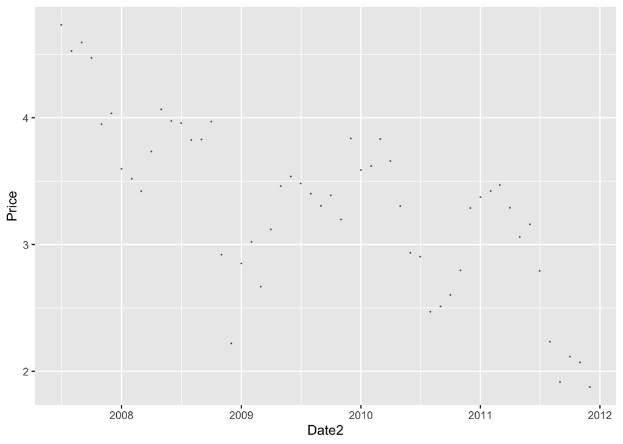

```r
#make the date of the bond file comparable to the lending club dataset
#for some regional date/number (locale) settings this may not work. If it does try running the following line of code in the Console
#Sys.setlocale("LC_TIME","English")
bond_prices <- bond_prices %>%
  mutate(Date2=as.Date(paste("01",Date,sep="-"),"%d-%b-%y")) %>%
  select(-starts_with("X"))

#let's see what happened to bond yields over time. Lower bond yields mean the cost of borrowing has gone down.

bond_prices %>%
  ggplot(aes(x=Date2, y=Price))+geom_point(size=0.1, alpha=0.5)
```

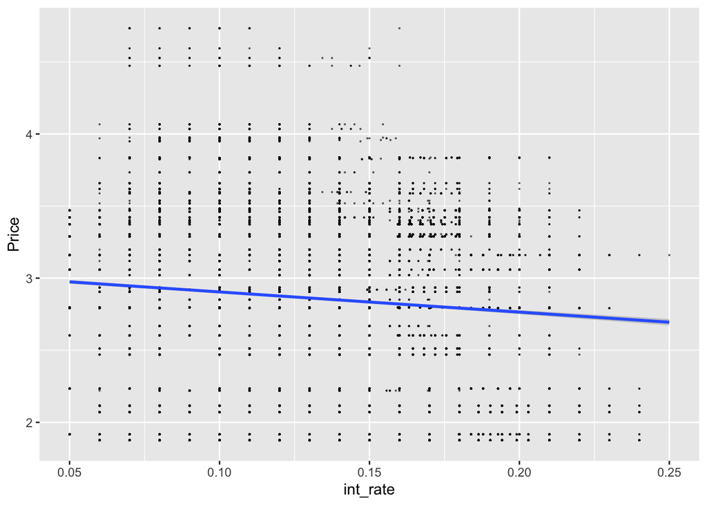

```r
#join the data using a left join
lc_with_bonds<-lc_clean %>%
  left_join(bond_prices, by = c("issue_d" = "Date2")) %>%
  arrange(issue_d) %>%
  filter(!is.na(Price)) #drop any observations where there re no bond prices available

# investigate graphically if there is a relationship
lc_with_bonds%>%
  ggplot(aes(x=int_rate, y=Price))+geom_point(size=0.1, alpha=0.5)+geom_smooth(method="lm")
```

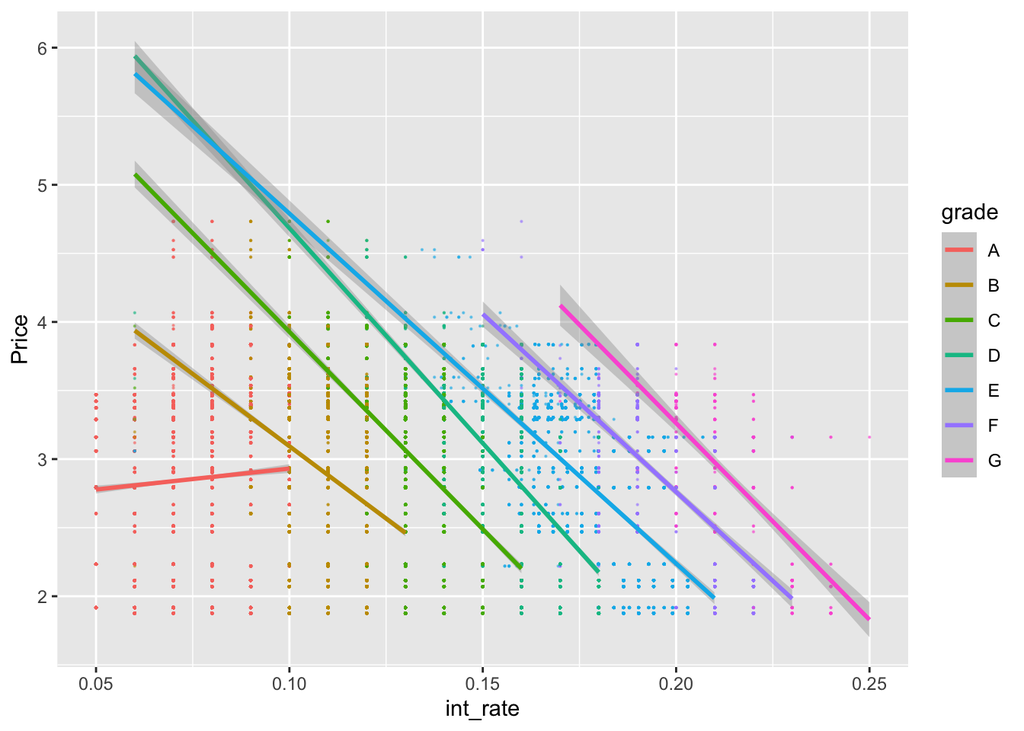

```r
lc_with_bonds%>%
  ggplot(aes(x=int_rate, y=Price, color=grade))+geom_point(size=0.1, alpha=0.5)+geom_smooth(method="lm")
```

```r
#let's train a model using the bond information


plsFit<-train(
    int_rate ~loan_amnt*grade+ term+ dti + Price*grade , #fill your variables here
    lc_with_bonds,
   method = "lm",
    trControl = control
   )
summary(plsFit)
```

```
##
## Call:
## lm(formula = .outcome ~ ., data = dat)
##
## Residuals:
##       Min        1Q    Median        3Q       Max
## -0.117450 -0.005810 -0.000302  0.006494  0.040734
##
## Coefficients:
##                      Estimate Std. Error t value Pr(>|t|)
## (Intercept)         6.791e-02  5.361e-04 126.679  < 2e-16 ***
## loan_amnt           1.795e-07  1.863e-08   9.638  < 2e-16 ***
## gradeB              5.350e-02  6.990e-04  76.538  < 2e-16 ***
## gradeC              8.631e-02  7.843e-04 110.051  < 2e-16 ***
## gradeD              1.192e-01  8.941e-04 133.269  < 2e-16 ***
## gradeE              1.433e-01  1.167e-03 122.786  < 2e-16 ***
## gradeF              1.667e-01  1.791e-03  93.096  < 2e-16 ***
## gradeG              1.903e-01  3.456e-03  55.057  < 2e-16 ***
## term60              1.506e-03  1.323e-04  11.378  < 2e-16 ***
## dti                 2.802e-05  7.453e-06   3.760 0.000171 ***
## Price               1.301e-03  1.626e-04   8.005 1.22e-15 ***
## `loan_amnt:gradeB` -9.477e-08  2.249e-08  -4.214 2.51e-05 ***
## `loan_amnt:gradeC` -2.195e-07  2.416e-08  -9.088  < 2e-16 ***
## `loan_amnt:gradeD` -1.987e-09  2.572e-08  -0.077 0.938417
## `loan_amnt:gradeE`  6.441e-08  2.787e-08   2.311 0.020827 *
## `loan_amnt:gradeF`  6.990e-08  3.840e-08   1.820 0.068693 .
## `loan_amnt:gradeG` -1.206e-07  6.770e-08  -1.781 0.074911 .
## `gradeB:Price`     -5.774e-03  2.181e-04 -26.470  < 2e-16 ***
## `gradeC:Price`     -8.000e-03  2.429e-04 -32.934  < 2e-16 ***
## `gradeD:Price`     -1.274e-02  2.794e-04 -45.585  < 2e-16 ***
## `gradeE:Price`     -1.527e-02  3.611e-04 -42.287  < 2e-16 ***
## `gradeF:Price`     -1.667e-02  5.359e-04 -31.103  < 2e-16 ***
## `gradeG:Price`     -1.780e-02  9.982e-04 -17.829  < 2e-16 ***
## ---
## Signif. codes:  0 '***' 0.001 '**' 0.01 '*' 0.05 '.' 0.1 ' ' 1
##
## Residual standard error: 0.009584 on 37845 degrees of freedom
## Multiple R-squared:  0.9339, Adjusted R-squared:  0.9339
## F-statistic: 2.43e+04 on 22 and 37845 DF,  p-value: < 2.2e-16
```

## Q10. Choose a model and describe your methodology

Feel free to investigate more models with different features using the methodologies covered so far. Present the model you believe predicts interest rates the best. Describe how good it is (including the approximate length of the 95% Confidence Interval of predictions that use this model) and what features it uses. What methodology did you use to choose it? (Do not use time trends or quarter dummies in your model as the first cannot be extrapolated into the future reliably and the second cannot be even estimated for future quarters.)

```r
lc_with_yq_bonds<- lc_with_bonds %>%
  mutate(yq = as.factor(as.yearqtr(issue_d, format = "%Y-%m-%d")))

model_wild_west <- train(
    int_rate ~loan_amnt*grade+ term+ dti + poly(Price, 3)*grade, #fill your variables here
    lc_with_yq_bonds,
   method = "lm",
    trControl = control
   )
summary(model_wild_west)
```

```
##
## Call:
## lm(formula = .outcome ~ ., data = dat)
##
## Residuals:
##       Min        1Q    Median        3Q       Max
## -0.114899 -0.006111  0.000080  0.006341  0.041524
##
## Coefficients:
##                            Estimate Std. Error t value Pr(>|t|)
## (Intercept)               7.170e-02  2.062e-04 347.715  < 2e-16 ***
## loan_amnt                 1.771e-07  1.838e-08   9.638  < 2e-16 ***
## gradeB                    3.692e-02  2.470e-04 149.477  < 2e-16 ***
## gradeC                    6.338e-02  2.713e-04 233.592  < 2e-16 ***
## gradeD                    8.281e-02  3.160e-04 262.055  < 2e-16 ***
## gradeE                    9.977e-02  4.243e-04 235.133  < 2e-16 ***
## gradeF                    1.190e-01  7.096e-04 167.760  < 2e-16 ***
## gradeG                    1.402e-01  1.445e-03  97.073  < 2e-16 ***
## term60                    1.678e-03  1.321e-04  12.702  < 2e-16 ***
## dti                       2.666e-05  7.360e-06   3.622 0.000293 ***
## `poly(Price, 3)1`         1.640e-01  1.904e-02   8.614  < 2e-16 ***
## `poly(Price, 3)2`         3.282e-01  1.890e-02  17.369  < 2e-16 ***
## `poly(Price, 3)3`        -5.334e-02  1.796e-02  -2.970 0.002977 **
## `loan_amnt:gradeB`       -1.057e-07  2.221e-08  -4.761 1.93e-06 ***
## `loan_amnt:gradeC`       -2.275e-07  2.385e-08  -9.537  < 2e-16 ***
## `loan_amnt:gradeD`       -2.769e-08  2.545e-08  -1.088 0.276645
## `loan_amnt:gradeE`        3.504e-08  2.768e-08   1.266 0.205536
## `loan_amnt:gradeF`        4.849e-08  3.820e-08   1.270 0.204262
## `loan_amnt:gradeG`       -1.688e-07  6.741e-08  -2.504 0.012273 *
## `gradeB:poly(Price, 3)1` -6.953e-01  2.555e-02 -27.217  < 2e-16 ***
## `gradeC:poly(Price, 3)1` -9.351e-01  2.853e-02 -32.776  < 2e-16 ***
## `gradeD:poly(Price, 3)1` -1.537e+00  3.275e-02 -46.930  < 2e-16 ***
## `gradeE:poly(Price, 3)1` -1.833e+00  4.297e-02 -42.658  < 2e-16 ***
## `gradeF:poly(Price, 3)1` -1.967e+00  6.324e-02 -31.094  < 2e-16 ***
## `gradeG:poly(Price, 3)1` -2.205e+00  1.334e-01 -16.529  < 2e-16 ***
## `gradeB:poly(Price, 3)2` -1.284e-01  2.581e-02  -4.973 6.62e-07 ***
## `gradeC:poly(Price, 3)2` -4.488e-01  2.740e-02 -16.381  < 2e-16 ***
## `gradeD:poly(Price, 3)2` -2.985e-01  3.263e-02  -9.147  < 2e-16 ***
## `gradeE:poly(Price, 3)2` -2.612e-01  4.497e-02  -5.809 6.35e-09 ***
## `gradeF:poly(Price, 3)2` -3.536e-01  6.094e-02  -5.802 6.61e-09 ***
## `gradeG:poly(Price, 3)2`  5.936e-02  1.739e-01   0.341 0.732898
## `gradeB:poly(Price, 3)3` -8.692e-02  2.552e-02  -3.406 0.000659 ***
## `gradeC:poly(Price, 3)3` -1.702e-01  2.664e-02  -6.387 1.71e-10 ***
## `gradeD:poly(Price, 3)3` -3.553e-01  3.385e-02 -10.496  < 2e-16 ***
## `gradeE:poly(Price, 3)3` -3.433e-01  4.443e-02  -7.727 1.13e-14 ***
## `gradeF:poly(Price, 3)3` -2.343e-01  5.338e-02  -4.390 1.14e-05 ***
## `gradeG:poly(Price, 3)3` -4.176e-01  1.825e-01  -2.288 0.022128 *
## ---
## Signif. codes:  0 '***' 0.001 '**' 0.01 '*' 0.05 '.' 0.1 ' ' 1
##
## Residual standard error: 0.009452 on 37831 degrees of freedom
## Multiple R-squared:  0.9357, Adjusted R-squared:  0.9357
## F-statistic: 1.53e+04 on 36 and 37831 DF,  p-value: < 2.2e-16
```

```r
0.009452*1.96
```

```
## [1] 0.01852592
```